# 2) Exploring ARFA and GRM

2026-06-26

```r
library(psych) # fa.parallel()
library(tidyverse)
library(gt)
library(skimr) #skim()
library(kableExtra) #kbl()
library(mirt) #mirt()
library(caret) #findCorrelation()
library(ggmirt) #tracePlot()
library(patchwork)
```

# Reading in ARFA Subtest Dataset

Here we will be reading in the ARFA spelling error data. This data has already been processed from an earlier script where each item had the potential to have several different types of errors. For example, each item had 7 variables where scores were given to indicate errors or even Russian words were used. No errors were rows where each of the 7 variables had all 0’s, which was most of the dataset. What we are reading in below are **sum of errors for each item** capped at two (0, 1, 2). We capped it at two because that was recommended to us.

The task while in Russian, we can translate the 22 items down below:

1. Pardon
2. Compromise
3. Disciplined
4. Gouache
5. Fairly
6. Greenhouse
7. Supernatural
8. Uninspired
9. Away
10. Trajectory
11. Rely
12. Puddle
13. The flower couldn’t grow long without being watered
14. At this bachelorette party, all the girls were inmarried
15. The birdcatcher waiter in the forest until midnight
16. Not all Zurich residents speak French
17. They hate sunbathing
18. She had nothing to thank him for
19. The train arrived at the northeast station
20. At ninety-five years old, her heart was still working well
21. What time did he sent out to meet the guests
22. The warrior is skilled with the sword

The participant was played an audio recording of the words/sentences and then had to spell it out correctly.

### Visualizing ARFA Spelling Data Descriptives for Error

Descriptive Statistics of Spelling Total Error Score

| vars | n | mean | sd | median | trimmed | mad | min | max | range | skew | kurtosis | se |
| --- | --- | --- | --- | --- | --- | --- | --- | --- | --- | --- | --- | --- |
| 1 | 658 | 14.95 | 9.63 | 13 | 14.13 | 10.38 | 0 | 41 | 41 | 0.65 | -0.41 | 0.38 |

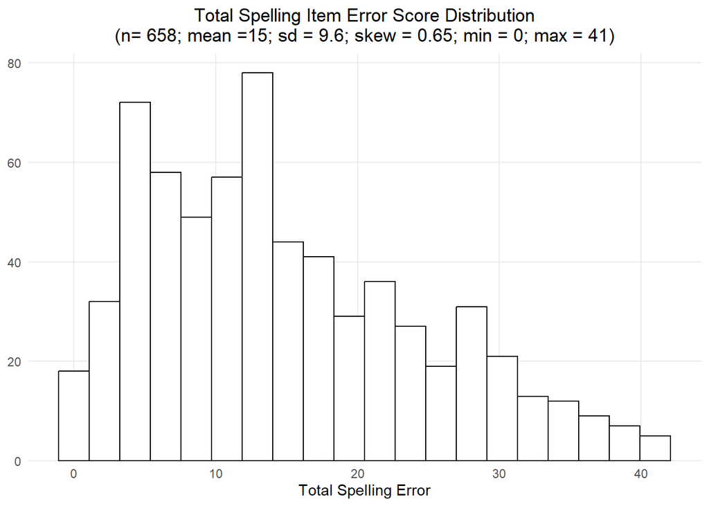

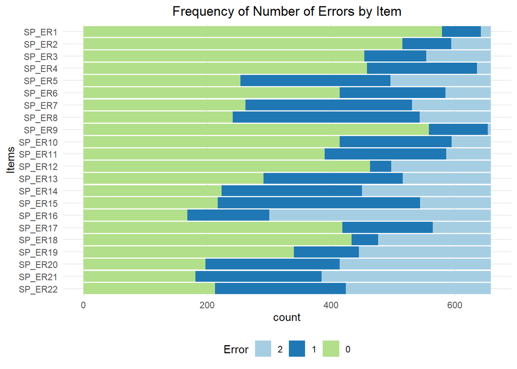

A: ARFA Subtest Probability of Response Category Endorsement by Item

| Item | 0 | 1 | 2 |
| --- | --- | --- | --- |
| SP_ER1 | 0.88 | 0.10 | 0.02 |
| SP_ER2 | 0.78 | 0.12 | 0.10 |
| SP_ER3 | 0.69 | 0.15 | 0.16 |
| SP_ER4 | 0.70 | 0.27 | 0.03 |
| SP_ER5 | 0.39 | 0.37 | 0.25 |
| SP_ER6 | 0.63 | 0.26 | 0.11 |
| SP_ER7 | 0.40 | 0.41 | 0.19 |
| SP_ER8 | 0.37 | 0.46 | 0.17 |
| SP_ER9 | 0.85 | 0.14 | 0.01 |
| SP_ER10 | 0.63 | 0.28 | 0.10 |
| SP_ER11 | 0.59 | 0.30 | 0.11 |
| SP_ER12 | 0.70 | 0.05 | 0.24 |
| SP_ER13 | 0.44 | 0.34 | 0.22 |
| SP_ER14 | 0.34 | 0.34 | 0.32 |
| SP_ER15 | 0.33 | 0.50 | 0.17 |
| SP_ER16 | 0.26 | 0.20 | 0.54 |
| SP_ER17 | 0.64 | 0.22 | 0.14 |
| SP_ER18 | 0.66 | 0.07 | 0.28 |
| SP_ER19 | 0.52 | 0.16 | 0.32 |
| SP_ER20 | 0.30 | 0.33 | 0.37 |
| SP_ER21 | 0.28 | 0.31 | 0.41 |
| SP_ER22 | 0.32 | 0.32 | 0.36 |

### Switching Spelling Errors to Spelling Scores

In this section we have decided to take each item and subtract its error score from the value 2. Essentially this changes the direction of the data, such that if no error mistakes were made on an item, then they would get a score of 2. Additionally, if someone made 2 or more error mistakes for an item, then their spelling score will be a 0.

Descriptive Statistics of Total Spelling Score

| vars | n | mean | sd | median | trimmed | mad | min | max | range | skew | kurtosis | se |
| --- | --- | --- | --- | --- | --- | --- | --- | --- | --- | --- | --- | --- |
| 1 | 658 | 29.05 | 9.63 | 31 | 29.87 | 10.38 | 3 | 44 | 41 | -0.65 | -0.41 | 0.38 |

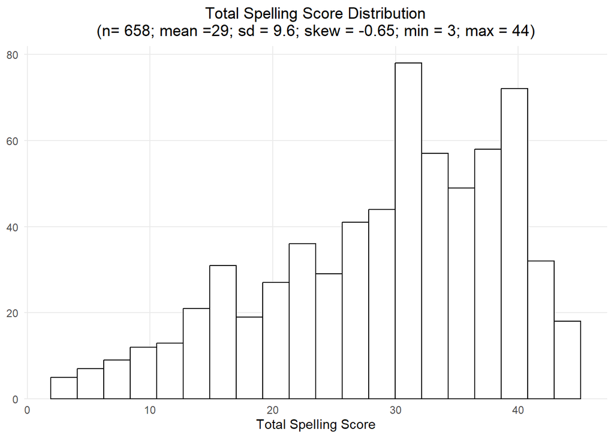

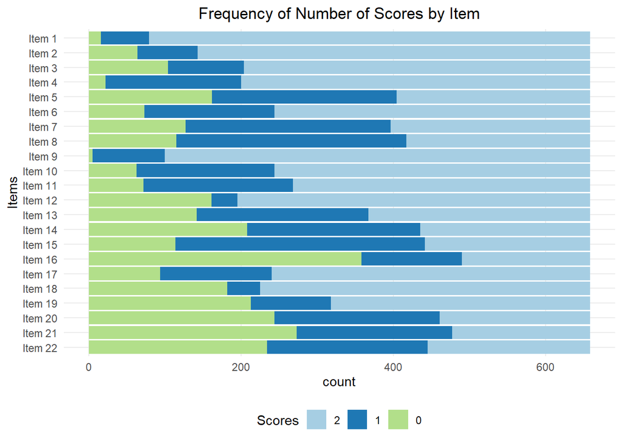

A: ARFA Subtest Probability of Response Category Endorsement by Item

| Item | 0 | 1 | 2 |
| --- | --- | --- | --- |
| Item 1 | 0.02 | 0.10 | 0.88 |
| Item 2 | 0.10 | 0.12 | 0.78 |
| Item 3 | 0.16 | 0.15 | 0.69 |
| Item 4 | 0.03 | 0.27 | 0.70 |
| Item 5 | 0.25 | 0.37 | 0.39 |
| Item 6 | 0.11 | 0.26 | 0.63 |
| Item 7 | 0.19 | 0.41 | 0.40 |
| Item 8 | 0.17 | 0.46 | 0.37 |
| Item 9 | 0.01 | 0.14 | 0.85 |
| Item 10 | 0.10 | 0.28 | 0.63 |
| Item 11 | 0.11 | 0.30 | 0.59 |
| Item 12 | 0.24 | 0.05 | 0.70 |
| Item 13 | 0.22 | 0.34 | 0.44 |
| Item 14 | 0.32 | 0.34 | 0.34 |
| Item 15 | 0.17 | 0.50 | 0.33 |
| Item 16 | 0.54 | 0.20 | 0.26 |
| Item 17 | 0.14 | 0.22 | 0.64 |
| Item 18 | 0.28 | 0.07 | 0.66 |
| Item 19 | 0.32 | 0.16 | 0.52 |
| Item 20 | 0.37 | 0.33 | 0.30 |
| Item 21 | 0.41 | 0.31 | 0.28 |
| Item 22 | 0.36 | 0.32 | 0.32 |

# Preparing for a Graded Response Model

The following next sections are heavily inspired by:

- “Getting started with the graded response model: An introduction and tutorial in R” by Rizqy Amelia Zein and Hanif Akhtar

### Testing Data Unidimensionallity

Before we can specify the GRM on our spelling data, we need to investigate that our data is **unidimensional**. This means that the items within our data have a similar general correlation with each other and that there are not subset of items that correlate highly with each other, which would indicate that they may be measuring something kinda different or very specific to spelling errors.

There are few ways to go about this.

The first approach is to calculate the polychoric corelations of the ARFA items and input that into the fa() function to run an exploratory factor analysis (EFA). We specified **two factors** to see how much of the variance each factor would explain. The first factor explains 47% of the variance while the second factor explains 3%. This gives us strong confidence that a general factor best explains the data since an additional factor basically contributed very little.

```r
# Create a matrix of polychoric correlations
cor <- polychoric(ARFA_items)

# Run an exploratory factor analysis with two factors
efa2 <- fa(cor$rho, nfactors = 2, fm = "minres") # Now, running EFA.
efa2$Vaccounted
```

```
                             MR1        MR2
SS loadings           10.2831440 0.66580574
Proportion Var         0.4674156 0.03026390
Cumulative Var         0.4674156 0.49767953
Proportion Explained   0.9391900 0.06081001
Cumulative Proportion  0.9391900 1.00000000
```

Here we took output from the EFA and plotted it (called a Scree Plot), specifically the Eigenvalues across factors. While in the EFA we specified two, here we get as many Eigenvalues as there are items in the data. Similar to the output from above, almost all of the variance of the data is well explained by one factor, showcasing evidence for unidimensionality. Basically, sine only one factor is above the red line, we have unidimensionality.

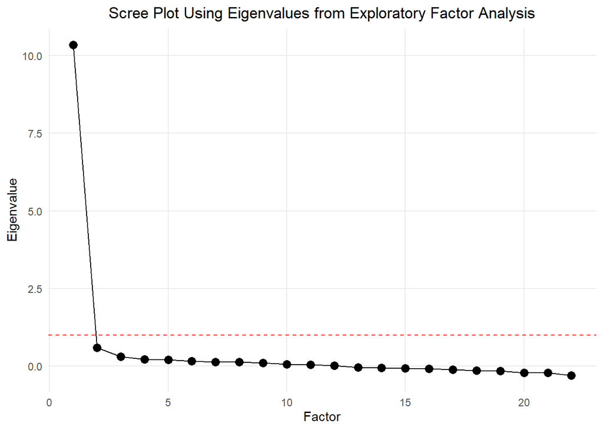

The best approach, however, is to use the fa.parallel() function from the psych package. It also states that one factor best explains the data- thus we have evidence that **our data are unidimensional**.

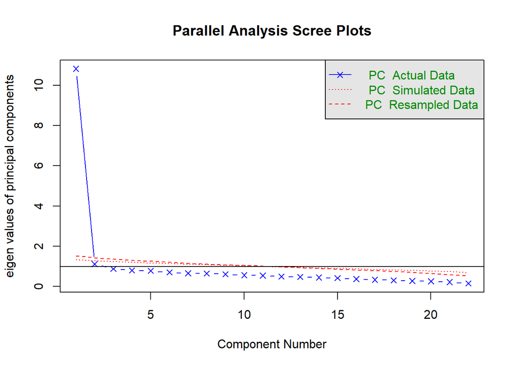

```
Parallel analysis suggests that the number of factors =  NA  and the number of components =  1
```

```r
# Parallel analysis
fa.parallel(ARFA_items, fm="minres", fa="pc",  cor = "poly")
```

### Running a Polytomous Graded Response Model (GRM)

From the descriptive section of the ARFA spelling task, after recoding the scores, we can see that each item contains 3 different types of categories (2 points, 1 point, 0 points) and that this information is in an ordinal scale (2 > 1 > 0). Thus, we can use a **polytomous graded response model** to basically estimate difficulty and discrimination parameters for each item. For the difficulty parameters, the model will be estimating two, which represent the level of ability where the item has a 50% change of having endorsement between category 0 and category 1 (and higher) and between category 1 and category 2.

In the code below we essentially write mod = ‘theta = 1-22’, which basically means we are specifying a undimensional dataset with 22 items.

```
We have data from 658 participants
```

```r
# Specify the model
mod <- paste0("theta = 1-", length(ARFA_items))

# Run the mirt model and produce the theta scores
fit_mirt <- mirt(ARFA_items,
                 1,
                 model = mod,
                 itemtype = "graded",
                 SE = TRUE,
                 technical = list(NCYCLES = 20000))
```

### Investigating Slope Parameters and Item Level Statistics

To kill two birds with one stone- we are right now prioritizing identifying bad items. These can be defined as items with a low slope (less than 1) or an item level statistic with a very small p-value (less than .001)

**First** iteration of the model. A custom function was used to evaluate the items based on the output of the model by investigating the item slopes and item diagnostic tests.

```
From the inputted 22 items:
```

```
- 20 items had no problems
```

```
- Item 13, Item 19 were identified to have bad slopes
```

```
- Item 13 were identified to have misfit
```

**Second** iteration of the model. The model was fit to a subset of the data based on the removal of bad items from above. The custom function was now used on this data.

```
From the inputted 20 items:
```

```
- 19 items had no problems
```

```
-  were identified to have bad slopes
```

```
- Item 15 were identified to have misfit
```

```
From the inputted 19 items:
```

```
- 18 items had no problems
```

```
-  were identified to have bad slopes
```

```
- Item 11 were identified to have misfit
```

### Checking for Local Dependence

No correlation of residuals exceed 0.2, which means we are good! (No local dependence). We used I think it’s called Yen’s Q3 statistics.

```r
# Obtaining the residual correlations
q3 <- residuals(fit_mirt, type = "Q3")
```

```r
# Checking for local dependence
findCorrelation(q3, cutoff = 0.2, verbose = T)
```

```
All correlations <= 0.2
```

```
integer(0)
```

### Overall Model Performance

Next we can use the `M2()` function to get a sense of model fit. We set the type to be equal to C2 because that provides the best results for polytomous models. The M2 statistics is conceptually similar to the chi-square statistics (X2) in SEM, such that the null hypothesis means the model is fitting the data well. Our results are significant, which means it does not- but it is commonly known that a lot of times this test will be significant if the sample size is pretty large, which ours is.

Technically if we were to go off thresholds (even though we are advised not to), the model fit indices produced below show that the model does a good job at capturing the data.

```
           M2  df p RMSEA RMSEA_5 RMSEA_95 SRMSR   TLI   CFI
stats 222.816 152 0 0.027   0.019    0.034 0.032 0.994 0.995
```

```r
# Obtain the parameter estimates for each item
coefs <- coef(fit_mirt, IRTpars = TRUE, simplify = TRUE) # Saving model parameters (item discrimination (a) and threshold (b)) in a data frame.

# Get the model summary (factor loadings and communality)
mirt_sum <- summary(fit_mirt) # Displaying factor loadings and commonality.

# Create a dataframe from both objects that have item information
item_info <- cbind( coefs$items, mirt_sum$rotF, mirt_sum$h2) %>% data.frame()
```

A: Item Parameters

| Item | a (discrim.) | b1 | b2 | λ (loading) | h² (communality) |
| --- | --- | --- | --- | --- | --- |
| Item 1 | 1.770 | -2.842 | -1.650 | 0.721 | 0.520 |
| Item 2 | 2.243 | -1.671 | -1.008 | 0.797 | 0.635 |
| Item 3 | 2.692 | -1.195 | -0.585 | 0.845 | 0.714 |
| Item 4 | 1.261 | -3.214 | -0.861 | 0.595 | 0.354 |
| Item 5 | 1.819 | -0.928 | 0.419 | 0.730 | 0.533 |
| Item 6 | 1.681 | -1.762 | -0.464 | 0.703 | 0.494 |
| Item 7 | 1.685 | -1.226 | 0.391 | 0.704 | 0.495 |
| Item 8 | 1.145 | -1.681 | 0.596 | 0.558 | 0.312 |
| Item 9 | 1.115 | -4.895 | -1.880 | 0.548 | 0.300 |
| Item 10 | 2.097 | -1.726 | -0.438 | 0.776 | 0.603 |
| Item 11 | 2.490 | -1.517 | -0.284 | 0.826 | 0.682 |
| Item 12 | 1.560 | -1.054 | -0.820 | 0.676 | 0.456 |
| Item 14 | 1.050 | -0.885 | 0.800 | 0.525 | 0.276 |
| Item 16 | 2.722 | 0.150 | 0.807 | 0.848 | 0.719 |
| Item 17 | 1.803 | -1.499 | -0.481 | 0.727 | 0.529 |
| Item 18 | 1.564 | -0.911 | -0.631 | 0.677 | 0.458 |
| Item 20 | 1.617 | -0.502 | 0.734 | 0.689 | 0.474 |
| Item 21 | 1.638 | -0.351 | 0.827 | 0.693 | 0.481 |
| Item 22 | 1.676 | -0.518 | 0.669 | 0.702 | 0.492 |

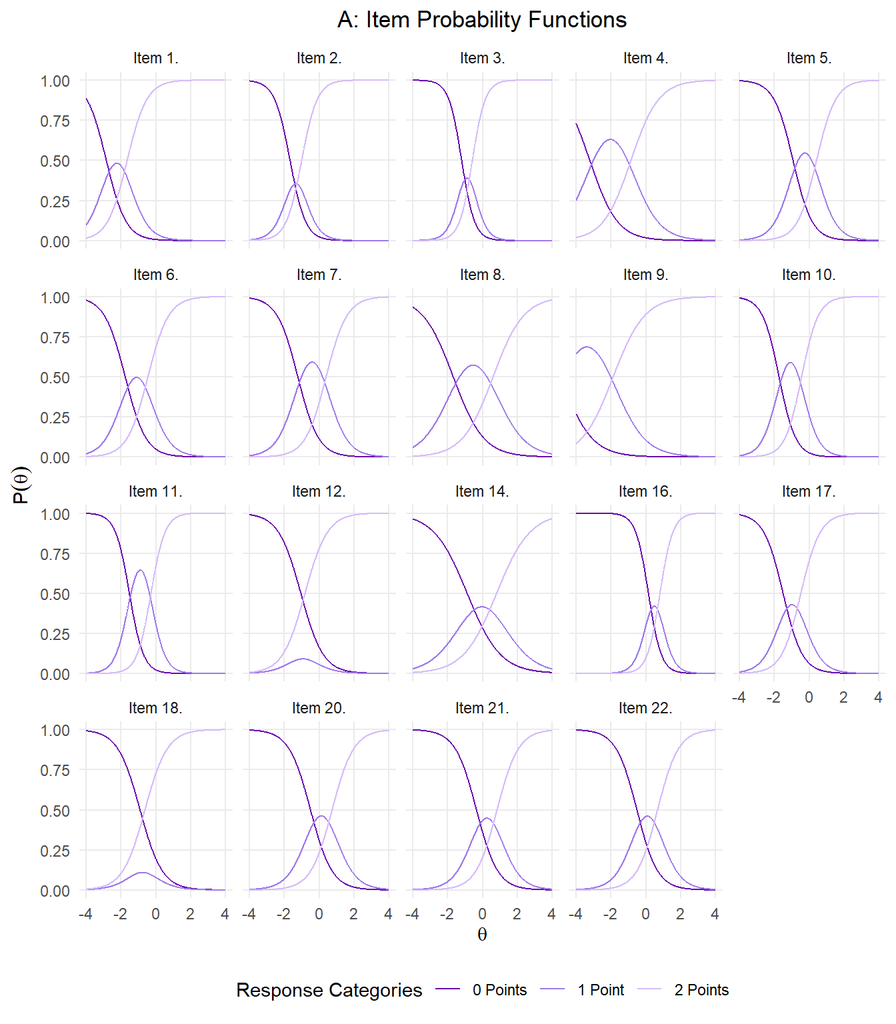

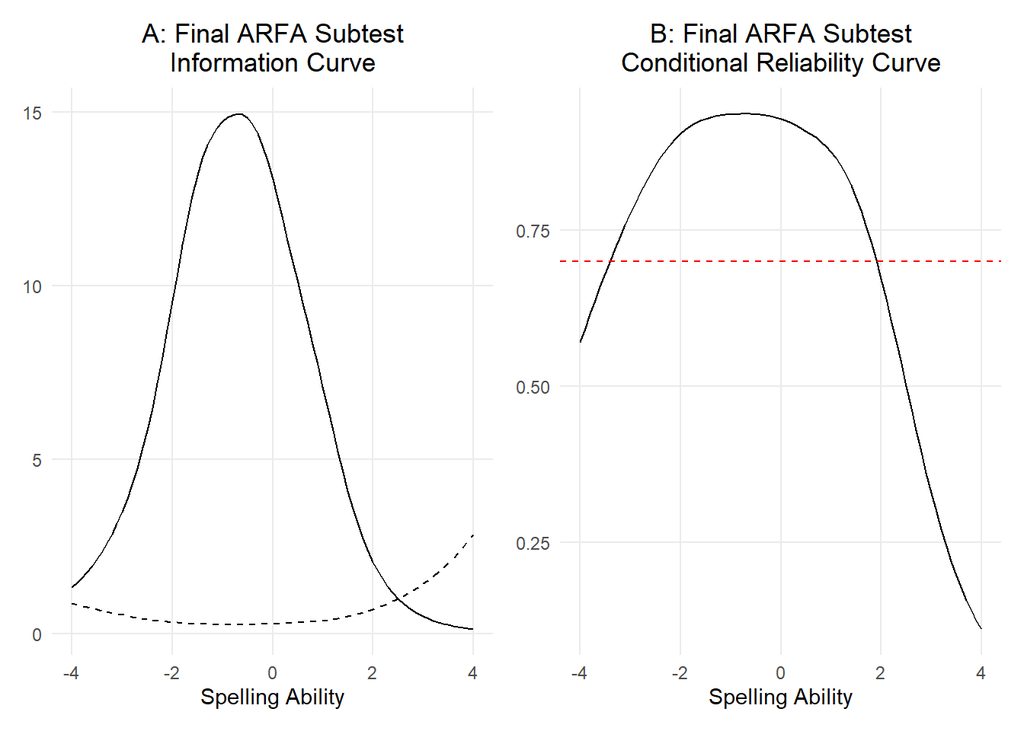

```
Reliability of .7 is present between -3.4 and 1.9 theta values
```

```
Reliability of .8 is present between -2.8 and 1.5 theta values
```

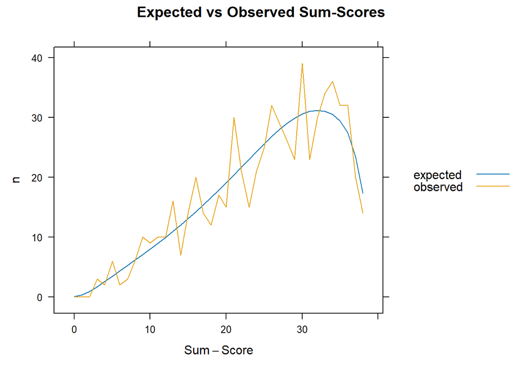

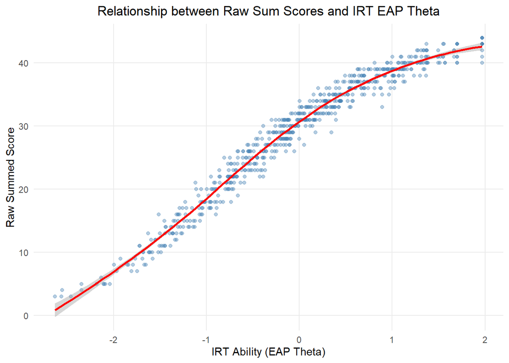

```
The correlation between raw scores and EAP scores is: 0.97
```

```r
# Change the working directory
setwd(clean_data_output)

# Save the ARFA data with the IRT scores
saveRDS(EAP_df, "2_ARFA_eap.rds")
```